```python
import pandas as pd
import numpy as np
import matplotlib.pyplot as plt
import requests
import os
import tweepy
import json
import seaborn as sns
%matplotlib inline
```

# Part I: Gathering Data

For this section, I will be accessing and reading in the three separate sources of data to be used for this project, namely the WeRateDogs' twitter archive, the image prediction file, as well as additional twitter data scraped using Tweepy

### 1. Accessing the WeRateDogs twitter archive as an already available .csv file

```python
archive = pd.read_csv('twitter-archive-enhanced.csv')
```

```python
archive.sample(10)
```

|  | tweet_id | in_reply_to_status_id | in_reply_to_user_id | timestamp | source | text | retweeted_status_id | retweeted_status_user_id | retweeted_status_timestamp | expanded_urls | rating_numerator | rating_denominator | name | doggo | floofer | pupper | puppo |
| --- | --- | --- | --- | --- | --- | --- | --- | --- | --- | --- | --- | --- | --- | --- | --- | --- | --- |
| 989 | 748932637671223296 | NaN | NaN | 2016-07-01 17:33:49 +0000 | <a href="http://twitter.com/download/iphone" r... | Say hello to Divine Doggo. Must be magical af.... | NaN | NaN | NaN | https://twitter.com/dog_rates/status/748932637... | 13 | 10 | Divine | doggo | None | None | None |
| 1260 | 710269109699739648 | NaN | NaN | 2016-03-17 00:58:46 +0000 | <a href="http://twitter.com/download/iphone" r... | The squad is back for St. Patrick's Day! ☘ 💚\n... | NaN | NaN | NaN | https://twitter.com/dog_rates/status/710269109... | 13 | 10 | None | None | None | None | None |
| 432 | 820749716845686786 | NaN | NaN | 2017-01-15 21:49:15 +0000 | <a href="http://twitter.com/download/iphone" r... | Meet Sunny. He can take down a polar bear in o... | NaN | NaN | NaN | https://twitter.com/dog_rates/status/820749716... | 13 | 10 | Sunny | None | None | None | None |
| 2258 | 667724302356258817 | NaN | NaN | 2015-11-20 15:20:54 +0000 | <a href="http://twitter.com" rel="nofollow">Tw... | What a dog to start the day with. Very calm. L... | NaN | NaN | NaN | https://twitter.com/dog_rates/status/667724302... | 7 | 10 | None | None | None | None | None |
| 1651 | 683498322573824003 | NaN | NaN | 2016-01-03 04:01:13 +0000 | <a href="http://twitter.com/download/iphone" r... | This is Griffin. He's desperate for both a phy... | NaN | NaN | NaN | https://twitter.com/dog_rates/status/683498322... | 11 | 10 | Griffin | None | None | None | None |
| 1485 | 693155686491000832 | NaN | NaN | 2016-01-29 19:36:08 +0000 | <a href="http://twitter.com/download/iphone" r... | This is Dunkin. He can only see when he's wet ... | NaN | NaN | NaN | https://twitter.com/dog_rates/status/693155686... | 12 | 10 | Dunkin | None | None | None | None |
| 0 | 892420643555336193 | NaN | NaN | 2017-08-01 16:23:56 +0000 | <a href="http://twitter.com/download/iphone" r... | This is Phineas. He's a mystical boy. Only eve... | NaN | NaN | NaN | https://twitter.com/dog_rates/status/892420643... | 13 | 10 | Phineas | None | None | None | None |
| 1571 | 687704180304273409 | NaN | NaN | 2016-01-14 18:33:48 +0000 | <a href="http://twitter.com/download/iphone" r... | Say hello to Blakely. He thinks that's a hat. ... | NaN | NaN | NaN | https://twitter.com/dog_rates/status/687704180... | 9 | 10 | Blakely | None | None | pupper | None |
| 1443 | 696744641916489729 | NaN | NaN | 2016-02-08 17:17:22 +0000 | <a href="http://vine.co" rel="nofollow">Vine -... | This is Klevin. He doesn't want his family bra... | NaN | NaN | NaN | https://vine.co/v/i1wrljBUjAu | 10 | 10 | Klevin | None | None | None | None |
| 494 | 813187593374461952 | NaN | NaN | 2016-12-26 01:00:05 +0000 | <a href="http://twitter.com/download/iphone" r... | We only rate dogs. Please don't send in other ... | NaN | NaN | NaN | https://twitter.com/dog_rates/status/813187593... | 13 | 10 | None | None | None | None | None |

### 2. Programmatically downloading the image predictions file

```python
prediction_url = 'https://d17h27t6h515a5.cloudfront.net/topher/2017/August/599fd2ad_image-predictions/image-predictions.tsv'

response = requests.get(prediction_url)
with open(prediction_url.split('/')[-1], mode='wb') as file:
    file.write(response.content)
```

```python
predictions = pd.read_csv('image-predictions.tsv', sep='\t')
predictions.sample(10)
```

|  | tweet_id | jpg_url | img_num | p1 | p1_conf | p1_dog | p2 | p2_conf | p2_dog | p3 | p3_conf | p3_dog |
| --- | --- | --- | --- | --- | --- | --- | --- | --- | --- | --- | --- | --- |
| 758 | 688789766343622656 | https://pbs.twimg.com/media/CY8SocAWsAARuyh.jpg | 1 | American_Staffordshire_terrier | 0.599660 | True | Staffordshire_bullterrier | 0.380976 | True | bull_mastiff | 0.003889 | True |
| 880 | 698635131305795584 | https://pbs.twimg.com/ext_tw_video_thumb/69863... | 1 | Samoyed | 0.158464 | True | kuvasz | 0.089402 | True | West_Highland_white_terrier | 0.025037 | True |
| 1805 | 832273440279240704 | https://pbs.twimg.com/ext_tw_video_thumb/83227... | 1 | Pembroke | 0.134081 | True | ice_bear | 0.051928 | False | pug | 0.044311 | True |
| 954 | 705223444686888960 | https://pbs.twimg.com/media/Ccl0-HVVAAAf8aK.jpg | 1 | Egyptian_cat | 0.090508 | False | Chesapeake_Bay_retriever | 0.077373 | True | Mexican_hairless | 0.049472 | True |
| 691 | 684200372118904832 | https://pbs.twimg.com/media/CX7EkuHWkAESLZk.jpg | 1 | llama | 0.681347 | False | ram | 0.120142 | False | hog | 0.043686 | False |
| 1684 | 814153002265309185 | https://pbs.twimg.com/media/C0xz04SVIAAeyDb.jpg | 1 | golden_retriever | 0.490068 | True | Labrador_retriever | 0.291956 | True | chow | 0.072475 | True |
| 299 | 671486386088865792 | https://pbs.twimg.com/media/CVGZTboUsAATohd.jpg | 1 | German_shepherd | 0.827035 | True | kelpie | 0.087648 | True | red_wolf | 0.031218 | False |
| 1117 | 725786712245440512 | https://pbs.twimg.com/media/ChKDKmIWIAIJP_e.jpg | 1 | chow | 0.335761 | True | Samoyed | 0.167173 | True | kuvasz | 0.145715 | True |
| 273 | 670832455012716544 | https://pbs.twimg.com/media/CU9GjzrUkAAWPh4.jpg | 1 | malinois | 0.317607 | True | Norwegian_elkhound | 0.274901 | True | bathing_cap | 0.114643 | False |
| 802 | 691459709405118465 | https://pbs.twimg.com/media/CZiO7mWUEAAa4zo.jpg | 1 | Shetland_sheepdog | 0.551206 | True | collie | 0.232544 | True | Border_collie | 0.095218 | True |

### 3. Using Tweepy to scrape for additional twitter data

```python
CONSUMER_KEY = "76XxoS3DEEfyd54s0i1sA2WHV"
CONSUMER_SECRET = "9pn4mBHmrJhu2Ykl7IGgSYt37VM6aMu35K1YKmy5C0j4tp8UWh"
OAUTH_TOKEN = "4271529793-FfUEEb5zx2QQDAF02Pq7EasGRwwP9wk4SEiSY36"
OAUTH_TOKEN_SECRET = "LLqBMMiyReRcRTpBukFDYGNCr8ubzfAoiixyKyBBH1AdQ"

auth = tweepy.OAuthHandler(CONSUMER_KEY, CONSUMER_SECRET)
auth.set_access_token(OAUTH_TOKEN, OAUTH_TOKEN_SECRET)
api = tweepy.API(auth)

id_list = archive['tweet_id'].tolist()

errors = []

with open(os.path.join(os.getcwd(), 'tweet_json.txt'), mode = 'w') as file:
    for twt_id in id_list:
        try:
            ranking = id_list.index(twt_id) + 1
            print(ranking)
            tweet = api.get_status(twt_id, tweet_mode = 'extended', wait_on_rate_limit=True, wait_on_rate_limit_notify=True)
            file.write(json.dumps(tweet._json) + '\n')
        except Exception as e:
            print(str(ranking) + '_' + str(twt_id) + ': ' + str(e))
            errors.append({'tweet_id': int(ranking),
                           'error': e,
                           'ranking': ranking})
```

[output not shown]

[output cut: 869 more lines]

[output not shown]

```
Rate limit reached. Sleeping for: 652
```

[output not shown]

[output cut: 847 more lines]

[output not shown]

```
Rate limit reached. Sleeping for: 653
```

[output not shown]

[output cut: 500 more lines]

[output not shown]

```python
# Reading each JSON file
twt_id = []
likes = []
retweets = []
with open('tweet_json.txt', mode = 'r') as f:
     for line in f.readlines():
            tweet_data = json.loads(line)
            twt_id.append(tweet_data['id'])
            likes.append(tweet_data['favorite_count'])
            retweets.append(tweet_data['retweet_count'])

tweet_data = pd.DataFrame({'tweet_id':twt_id, 'favorite_count':likes, 'retweet_count':retweets})
```

```python
tweet_data.head()
```

|  | tweet_id | favorite_count | retweet_count |
| --- | --- | --- | --- |
| 0 | 892420643555336193 | 36251 | 7718 |
| 1 | 892177421306343426 | 31258 | 5705 |
| 2 | 891815181378084864 | 23536 | 3781 |
| 3 | 891689557279858688 | 39527 | 7870 |
| 4 | 891327558926688256 | 37746 | 8489 |

# Part 2: Data Assessments

```python
archive.shape, predictions.shape, tweet_data.shape
```

```
((2356, 17), (2075, 12), (2331, 3))
```

**Observation**: not every tweet is captured is the predictions and tweet_data datasets. For the additional tweet data, some of the tweets have been deleted and/or I have no access to, therefore not every tweet from the archive was retrieved

```python
archive.info()
```

```
<class 'pandas.core.frame.DataFrame'>
RangeIndex: 2356 entries, 0 to 2355
Data columns (total 17 columns):
 #   Column                      Non-Null Count  Dtype
---  ------                      --------------  -----
 0   tweet_id                    2356 non-null   int64
 1   in_reply_to_status_id       78 non-null     float64
 2   in_reply_to_user_id         78 non-null     float64
 3   timestamp                   2356 non-null   object
 4   source                      2356 non-null   object
 5   text                        2356 non-null   object
 6   retweeted_status_id         181 non-null    float64
 7   retweeted_status_user_id    181 non-null    float64
 8   retweeted_status_timestamp  181 non-null    object
 9   expanded_urls               2297 non-null   object
 10  rating_numerator            2356 non-null   int64
 11  rating_denominator          2356 non-null   int64
 12  name                        2356 non-null   object
 13  doggo                       2356 non-null   object
 14  floofer                     2356 non-null   object
 15  pupper                      2356 non-null   object
 16  puppo                       2356 non-null   object
dtypes: float64(4), int64(3), object(10)
memory usage: 313.0+ KB
```

```python
sum(archive.tweet_id.duplicated())
```

```
0
```

```python
archive.rating_denominator.value_counts()
```

```
10     2333
11        3
50        3
80        2
20        2
2         1
16        1
40        1
70        1
15        1
90        1
110       1
120       1
130       1
150       1
170       1
7         1
0         1
Name: rating_denominator, dtype: int64
```

```python
archive.name.value_counts()
```

```
None         745
a             55
Charlie       12
Lucy          11
Cooper        11
            ...
Amber          1
Nida           1
Bradley        1
Alejandro      1
Wishes         1
Name: name, Length: 957, dtype: int64
```

**Observations:**

- We only want to keep original rating from WeRateDogs, and not replys or retweets from other accounts. Therefore, tweets (rows) containing data in the columns `in_reply_to_status_id`, `in_reply_to_user_id`, `retweeted_status_id`, `retweeted_status_timestamp`, `retweeted_status_user_id` are not original and should be dropped
- The column `source` isn't particularly useful and contain similar data to `extended_url`.
- Wrong datatypes for tweet_id, timestamp
- "doggo", "floofer", "pupper", "puppo" should be one column as opposed to four
- the `rating_denominator` for 23 out of 2356 tweets was a value other then 10. It is unsure whether these values were intentional or not, but because they only represent ~1% of the total tweets, as well as for the sake of consistency, I will change these values to 10
- 55 dogs were named "a", 8 named "the" and 7 named "an"

```python
predictions.info()
```

```
<class 'pandas.core.frame.DataFrame'>
RangeIndex: 2075 entries, 0 to 2074
Data columns (total 12 columns):
 #   Column    Non-Null Count  Dtype
---  ------    --------------  -----
 0   tweet_id  2075 non-null   int64
 1   jpg_url   2075 non-null   object
 2   img_num   2075 non-null   int64
 3   p1        2075 non-null   object
 4   p1_conf   2075 non-null   float64
 5   p1_dog    2075 non-null   bool
 6   p2        2075 non-null   object
 7   p2_conf   2075 non-null   float64
 8   p2_dog    2075 non-null   bool
 9   p3        2075 non-null   object
 10  p3_conf   2075 non-null   float64
 11  p3_dog    2075 non-null   bool
dtypes: bool(3), float64(3), int64(2), object(4)
memory usage: 152.1+ KB
```

```python
sum(predictions.tweet_id.duplicated())
```

```
0
```

```python
predictions.p1_dog.value_counts()
```

```
True     1532
False     543
Name: p1_dog, dtype: int64
```

**Observations:**

- only the first (most accurate) prediction should be kept
- "img_num" and "jpg_url" doesn't seem to be particularly useful
- wrong datatype for tweet_id
- 543 predictions were not pictures of dogs
- predictions of dog breed (`p1`) in `predictions` are separated by underscores(`_`), would be more vidually appealing if spaces were used
- inconsistencies in the capitalization of dog breeds (`p1`) in `predictions`

```python
tweet_data.info()
```

```
<class 'pandas.core.frame.DataFrame'>
RangeIndex: 2331 entries, 0 to 2330
Data columns (total 3 columns):
 #   Column          Non-Null Count  Dtype
---  ------          --------------  -----
 0   tweet_id        2331 non-null   int64
 1   favorite_count  2331 non-null   int64
 2   retweet_count   2331 non-null   int64
dtypes: int64(3)
memory usage: 54.8 KB
```

```python
# gathering up tweets that could not be collected from our API
error_list = []
for i in range(len(errors)):
    error_list.append(errors[i]['error'].args[0][0]['message'])
pd.Series(error_list).value_counts()
```

```
No status found with that ID.                        24
Sorry, you are not authorized to see this status.     1
dtype: int64
```

**Observations**:

- 25 tweets from the archive were not retrieved
- wrong datatype for tweet_id

### Summary of cleaning that needs to be completed

**Tidiness Issues**:

1. `doggo`, `floofer`, `pupper`, `puppo` should be one column as opposed to four
2. all three dataframes `archive`, `predictions`, `tweet_data` should be merged into a single dataframe

**Quality Issues**:

1. Wrong datatypes for `tweet_id` in all three tables (`int` should be `str`) as well as the `timestamp` column in `archive` (`str` should be `datetime`)
2. dropping columns and rows that are not particularly useful to our analysis
3. some predictions in the `prediction` dataset were not images of dogs
4. some `rating_denominator` in `archive` were not 10
5. **missing data!** Inconsistent number of entries between the three dataframes
6. predictions of dog breed (`p1`) in `predictions` are separated by underscores(`_`), would be more vidually appealing if spaces were used
7. inconsistencies in the capitalization of dog breeds (`p1`) in `predictions`
8. 55 dogs named "a", 8 dogs named "the" and 7 dogs named "an" in `archive`

# Part 3. Data Cleaning

I will be tackling the data cleaning tasks by each dataframe first before merging them into a final, clean dataframe. Issues related to missing data will be tackled last

```python
archive_clean = archive.copy()
predictions_clean = predictions.copy()
tweet_data_clean = tweet_data.copy()
```

### 1. `archive` data cleaning

Tasks:

**Tidiness Issues**:

1. `doggo`, `floofer`, `pupper`, `puppo` should be one column as opposed to four

**Quality Issues:**

1. changing the datatype for `tweet_id` to str, and `timestamp` to datetime
2. we only want to keep the tweets that were originally tweet by WeRateDogs, and not comments or retweets from another account
3. The `source` column isn't particularly useful and very similar to `extended_url`.
4. Changing the 23 tweets with a `rating_denominator` value other then 10 to 10.
5. Changing the names of the 55 dogs named "a", 8 named "the" and 7 named "an" all to None

**Tidiness issue 1:**

**Define**: I will be using an `np.where()` statement to filter out `doggo`, `fluffer`, `pupper`, `puppo` into a single column named `dog_stage`

**Code**

```python
# Checking what kinds of responses are contained within doggo, floofer, pupper, puppo
archive_clean.doggo.value_counts()
```

```
None     2259
doggo      97
Name: doggo, dtype: int64
```

```python
archive_clean.floofer.value_counts()
```

```
None       2346
floofer      10
Name: floofer, dtype: int64
```

```python
archive_clean.pupper.value_counts()
```

```
None      2099
pupper     257
Name: pupper, dtype: int64
```

```python
archive_clean.puppo.value_counts()
```

```
None     2326
puppo      30
Name: puppo, dtype: int64
```

```python
archive_clean['dog_stage'] = np.where(archive_clean['doggo'] == 'doggo', 'doggo', np.where(archive_clean['floofer'] == 'floofer', 'floofer', np.where(archive_clean['pupper'] == 'pupper', 'pupper', np.where(archive_clean['puppo'] == 'puppo', 'puppo', 'none'))))
```

**Test**

```python
archive_clean.dog_stage.value_counts()
```

```
none       1976
pupper      245
doggo        97
puppo        29
floofer       9
Name: dog_stage, dtype: int64
```

`doggo`, `fluffer`, `pupper`, `puppo` can now be dropped

```python
archive_clean = archive_clean.drop(['doggo', 'floofer', 'pupper', 'puppo'], axis=1)
```

**Quality Issue 1:**

**Define:** simply changing the datatype of `tweet_id` to `str` and `timestamp` to `datetime`

**Code**:

```python
archive_clean.tweet_id = archive_clean.tweet_id.astype(str)
archive_clean.timestamp = pd.to_datetime(archive_clean.timestamp)
```

**Test**

```python
archive_clean.info()
```

```
<class 'pandas.core.frame.DataFrame'>
RangeIndex: 2356 entries, 0 to 2355
Data columns (total 14 columns):
 #   Column                      Non-Null Count  Dtype
---  ------                      --------------  -----
 0   tweet_id                    2356 non-null   object
 1   in_reply_to_status_id       78 non-null     float64
 2   in_reply_to_user_id         78 non-null     float64
 3   timestamp                   2356 non-null   datetime64[ns, UTC]
 4   source                      2356 non-null   object
 5   text                        2356 non-null   object
 6   retweeted_status_id         181 non-null    float64
 7   retweeted_status_user_id    181 non-null    float64
 8   retweeted_status_timestamp  181 non-null    object
 9   expanded_urls               2297 non-null   object
 10  rating_numerator            2356 non-null   int64
 11  rating_denominator          2356 non-null   int64
 12  name                        2356 non-null   object
 13  dog_stage                   2356 non-null   object
dtypes: datetime64[ns, UTC](1), float64(4), int64(2), object(7)
memory usage: 257.8+ KB
```

**Quality Issue 2&3:**

**Define:** tweets that are retweets and comments are not original, and thus can be dropped. Rows containing values for `in_reply_to_status_id`, `in_reply_to_user_id`, `retweeted_status_id`, `retweeted_status_timestamp`, `retweeted_status_user_id` are indicators of retweets/comments and thus should be dropped. `source` will also be dropped because its similar to `extended_url`

**Code:**

```python
archive_clean = archive_clean[(archive_clean['in_reply_to_status_id'].isnull()) & (archive_clean['retweeted_status_id'].isnull())]
```

```python
archive_clean.info()
```

```
<class 'pandas.core.frame.DataFrame'>
Int64Index: 2097 entries, 0 to 2355
Data columns (total 14 columns):
 #   Column                      Non-Null Count  Dtype
---  ------                      --------------  -----
 0   tweet_id                    2097 non-null   object
 1   in_reply_to_status_id       0 non-null      float64
 2   in_reply_to_user_id         0 non-null      float64
 3   timestamp                   2097 non-null   datetime64[ns, UTC]
 4   source                      2097 non-null   object
 5   text                        2097 non-null   object
 6   retweeted_status_id         0 non-null      float64
 7   retweeted_status_user_id    0 non-null      float64
 8   retweeted_status_timestamp  0 non-null      object
 9   expanded_urls               2094 non-null   object
 10  rating_numerator            2097 non-null   int64
 11  rating_denominator          2097 non-null   int64
 12  name                        2097 non-null   object
 13  dog_stage                   2097 non-null   object
dtypes: datetime64[ns, UTC](1), float64(4), int64(2), object(7)
memory usage: 245.7+ KB
```

Now that the rows containing values for `in_reply_to_status_id`, `in_reply_to_user_id`, `retweeted_status_id`, `retweeted_status_timestamp`, `retweeted_status_user_id` have been dropped, we can also drop these columns along with `source`

```python
archive_clean = archive_clean.drop(['in_reply_to_status_id', 'in_reply_to_user_id', 'retweeted_status_id', 'retweeted_status_timestamp', 'retweeted_status_user_id', 'source'], axis=1)
```

```python
archive_clean.info()
```

```
<class 'pandas.core.frame.DataFrame'>
Int64Index: 2097 entries, 0 to 2355
Data columns (total 8 columns):
 #   Column              Non-Null Count  Dtype
---  ------              --------------  -----
 0   tweet_id            2097 non-null   object
 1   timestamp           2097 non-null   datetime64[ns, UTC]
 2   text                2097 non-null   object
 3   expanded_urls       2094 non-null   object
 4   rating_numerator    2097 non-null   int64
 5   rating_denominator  2097 non-null   int64
 6   name                2097 non-null   object
 7   dog_stage           2097 non-null   object
dtypes: datetime64[ns, UTC](1), int64(2), object(5)
memory usage: 147.4+ KB
```

**Quality Issue 4:**

**Define**: for the sake of continuity, the 23 tweets with a `rating_denominator` of some value other than 10 will be replaced with 10. I'll do this by just assigning the entire column to a value of 10.

**Code:**

```python
archive_clean['rating_denominator'] = 10
```

**Test:**

```python
archive_clean['rating_denominator'].value_counts()
```

```
10    2097
Name: rating_denominator, dtype: int64
```

**Quality Issue 4:**

**Code:**

```python
archive_clean[(archive_clean['name'] == 'a') | (archive_clean['name'] == 'an') | (archive_clean['name'] == 'the')] = None
```

**Test:**

```python
archive_clean.query('name == "a" | name == "an" | name == "the"')
```

|  | tweet_id | timestamp | text | expanded_urls | rating_numerator | rating_denominator | name | dog_stage |
| --- | --- | --- | --- | --- | --- | --- | --- | --- |

### 2. `predictions` data cleaning

Tasks:

**Tidiness Issues**:

None

**Quality Issues:**

1. only the first (most accurate) prediction should be kept
2. `img_num` doesn't seem to be particularly useful
3. wrong datatype for tweet_id
4. 543 predictions were not pictures of dogs
5. predictions of dog breed (`p1`) in `predictions` are separated by underscores(`_`), would be more vidually appealing if spaces were used
6. inconsistencies in the capitalization of dog breeds (`p1`) in `predictions`

**Quality Issue 1&2:**

**Define:** Since the first prediction is the most accurate, the second and third predictions (along with their attribute columns) will be dropped. `img_num` doesn't seem particularly useful either so it will be dropped.

**Code**:

```python
predictions_clean.head()
```

|  | tweet_id | jpg_url | img_num | p1 | p1_conf | p1_dog | p2 | p2_conf | p2_dog | p3 | p3_conf | p3_dog |
| --- | --- | --- | --- | --- | --- | --- | --- | --- | --- | --- | --- | --- |
| 0 | 666020888022790149 | https://pbs.twimg.com/media/CT4udn0WwAA0aMy.jpg | 1 | Welsh_springer_spaniel | 0.465074 | True | collie | 0.156665 | True | Shetland_sheepdog | 0.061428 | True |
| 1 | 666029285002620928 | https://pbs.twimg.com/media/CT42GRgUYAA5iDo.jpg | 1 | redbone | 0.506826 | True | miniature_pinscher | 0.074192 | True | Rhodesian_ridgeback | 0.072010 | True |
| 2 | 666033412701032449 | https://pbs.twimg.com/media/CT4521TWwAEvMyu.jpg | 1 | German_shepherd | 0.596461 | True | malinois | 0.138584 | True | bloodhound | 0.116197 | True |
| 3 | 666044226329800704 | https://pbs.twimg.com/media/CT5Dr8HUEAA-lEu.jpg | 1 | Rhodesian_ridgeback | 0.408143 | True | redbone | 0.360687 | True | miniature_pinscher | 0.222752 | True |
| 4 | 666049248165822465 | https://pbs.twimg.com/media/CT5IQmsXIAAKY4A.jpg | 1 | miniature_pinscher | 0.560311 | True | Rottweiler | 0.243682 | True | Doberman | 0.154629 | True |

```python
predictions_clean = predictions_clean.drop(['p2', 'p2_conf', 'p2_dog', 'p3', 'p3_conf', 'p3_dog', 'img_num'], axis=1)
```

```python
predictions_clean.head()
```

|  | tweet_id | jpg_url | p1 | p1_conf | p1_dog |
| --- | --- | --- | --- | --- | --- |
| 0 | 666020888022790149 | https://pbs.twimg.com/media/CT4udn0WwAA0aMy.jpg | Welsh_springer_spaniel | 0.465074 | True |
| 1 | 666029285002620928 | https://pbs.twimg.com/media/CT42GRgUYAA5iDo.jpg | redbone | 0.506826 | True |
| 2 | 666033412701032449 | https://pbs.twimg.com/media/CT4521TWwAEvMyu.jpg | German_shepherd | 0.596461 | True |
| 3 | 666044226329800704 | https://pbs.twimg.com/media/CT5Dr8HUEAA-lEu.jpg | Rhodesian_ridgeback | 0.408143 | True |
| 4 | 666049248165822465 | https://pbs.twimg.com/media/CT5IQmsXIAAKY4A.jpg | miniature_pinscher | 0.560311 | True |

**Quality Issue 3:**

**Define:** changing the datatype of `tweet_id` from `int` to `str`

**Code:**

```python
predictions_clean.tweet_id = predictions_clean.tweet_id.astype(str)
```

**Test:**

```python
predictions_clean.info()
```

```
<class 'pandas.core.frame.DataFrame'>
RangeIndex: 2075 entries, 0 to 2074
Data columns (total 5 columns):
 #   Column    Non-Null Count  Dtype
---  ------    --------------  -----
 0   tweet_id  2075 non-null   object
 1   jpg_url   2075 non-null   object
 2   p1        2075 non-null   object
 3   p1_conf   2075 non-null   float64
 4   p1_dog    2075 non-null   bool
dtypes: bool(1), float64(1), object(3)
memory usage: 67.0+ KB
```

**Quality Issue 4:**

**Define:** for the sake of this project, as well as keeping in mind the purpose of WeRateDogs, I will be removing all the tweets which aren't dogs. For consistency, I will also keep a list of the tweet_ids and remove these tweets from `archive` and `tweet_data` as well.

**Code**:

```python
##Getting a list of non-dog tweet_ids

non_dog = [predictions_clean.tweet_id[i] for i in range(len(predictions_clean.p1_dog)) if predictions_clean.p1_dog[i] == False]
```

```python
len(non_dog), len(predictions_clean.query('p1_dog == False'))
```

```
(543, 543)
```

```python
for i in non_dog:
    predictions_clean = predictions_clean.drop(predictions_clean[predictions_clean.tweet_id == i].index)
```

**Test:**

```python
len(predictions_clean.query('p1_dog == False'))
```

```
0
```

**Quality Issue 5&6:**

**Define:** changing all `underscores`(_) used in dog breed column (`p1`) to `spaces`, and capitalize the first letter of each word in `p1`

**Code:**

```python
predictions_clean['p1'] = predictions_clean['p1'].str.replace('_', ' ', regex=True).str.title()
```

**Test:**

```python
predictions_clean['p1'].value_counts()
```

```
Golden Retriever      150
Labrador Retriever    100
Pembroke               89
Chihuahua              83
Pug                    57
                     ...
Silky Terrier           1
Japanese Spaniel        1
Groenendael             1
Clumber                 1
Standard Schnauzer      1
Name: p1, Length: 111, dtype: int64
```

### 3. `tweet_data` data cleaning

Tasks:

**Tidiness Issues**:

None

**Quality Issues:**

**Quality Issue 1:**

**Code**:

```python
tweet_data_clean.tweet_id = tweet_data_clean.tweet_id.astype(str)
tweet_data_clean.favorite_count = tweet_data_clean.favorite_count.astype(int)
tweet_data_clean.retweet_count = tweet_data_clean.retweet_count.astype(int)
```

```python
tweet_data_clean.info()
```

```
<class 'pandas.core.frame.DataFrame'>
RangeIndex: 2331 entries, 0 to 2330
Data columns (total 3 columns):
 #   Column          Non-Null Count  Dtype
---  ------          --------------  -----
 0   tweet_id        2331 non-null   object
 1   favorite_count  2331 non-null   int64
 2   retweet_count   2331 non-null   int64
dtypes: int64(2), object(1)
memory usage: 54.8+ KB
```

### 4. Merging `archive_clean`, `predictions_clean` and `tweet_data_clean` into a final dataframe and addressing missing value issue

```python
archive_clean.shape, predictions_clean.shape, tweet_data_clean.shape
```

```
((2097, 8), (1532, 5), (2331, 3))
```

As we can see, the number of tweets between all three datasets are inconsistent for various reasons. One complication which we must first address is figuring out which dataset to use as the model for the merge. We previously filtered all tweets that were retweets and comments from `archive`, but still exist in the `predictions` and `tweet_data` datasets. On the other hand, we filter out all tweets that weren't dogs from `predictions`, however these still exist within `archive` and `tweet_data`. The simplest method that maintains the most data would be to remove all "nondog" data from `archive`, and to merge `predictions` and `tweet_data` onto archive.

```python
# remove nondog data from archive_clean

for i in non_dog:
    archive_clean = archive_clean.drop(archive_clean[archive_clean.tweet_id == i].index)
```

```python
archive_clean.shape
```

```
(1605, 8)
```

```python
# merge predictions_clean and tweet_data_clean onto archive_clean

df_temp = archive_clean.merge(predictions_clean, how = 'left', left_on='tweet_id', right_on='tweet_id')
WRD_clean = df_temp.merge(tweet_data_clean, how='left', left_on='tweet_id', right_on='tweet_id')
```

```python
WRD_clean.head()
```

|  | tweet_id | timestamp | text | expanded_urls | rating_numerator | rating_denominator | name | dog_stage | jpg_url | p1 | p1_conf | p1_dog | favorite_count | retweet_count |
| --- | --- | --- | --- | --- | --- | --- | --- | --- | --- | --- | --- | --- | --- | --- |
| 0 | 892177421306343426 | 2017-08-01 00:17:27+00:00 | This is Tilly. She's just checking pup on you.... | https://twitter.com/dog_rates/status/892177421... | 13.0 | 10.0 | Tilly | none | https://pbs.twimg.com/media/DGGmoV4XsAAUL6n.jpg | Chihuahua | 0.323581 | True | 31258.0 | 5705.0 |
| 1 | 891815181378084864 | 2017-07-31 00:18:03+00:00 | This is Archie. He is a rare Norwegian Pouncin... | https://twitter.com/dog_rates/status/891815181... | 12.0 | 10.0 | Archie | none | https://pbs.twimg.com/media/DGBdLU1WsAANxJ9.jpg | Chihuahua | 0.716012 | True | 23536.0 | 3781.0 |
| 2 | 891327558926688256 | 2017-07-29 16:00:24+00:00 | This is Franklin. He would like you to stop ca... | https://twitter.com/dog_rates/status/891327558... | 12.0 | 10.0 | Franklin | none | https://pbs.twimg.com/media/DF6hr6BUMAAzZgT.jpg | Basset | 0.555712 | True | 37746.0 | 8489.0 |
| 3 | 891087950875897856 | 2017-07-29 00:08:17+00:00 | Here we have a majestic great white breaching ... | https://twitter.com/dog_rates/status/891087950... | 13.0 | 10.0 | None | none | https://pbs.twimg.com/media/DF3HwyEWsAABqE6.jpg | Chesapeake Bay Retriever | 0.425595 | True | 19007.0 | 2841.0 |
| 4 | 890971913173991426 | 2017-07-28 16:27:12+00:00 | Meet Jax. He enjoys ice cream so much he gets ... | https://gofundme.com/ydvmve-surgery-for-jax,ht... | 13.0 | 10.0 | Jax | none | https://pbs.twimg.com/media/DF1eOmZXUAALUcq.jpg | Appenzeller | 0.341703 | True | 11071.0 | 1851.0 |

### 5. Final cleanings

**Quality Issues:**

1. `p1`, `p1_conf`, `jpg_url` and `expanded_urls` should be changed to `predicted_dog_breed`, `prediction_confidence`, `image_url` and `tweet_url` for clarity
2. since all non-dog tweets were dropped, the column `p1_dog` can also be dropped
3. minor fix: reorder `image_url` and `tweet_url` to the right-side of the table

**Quality Issue 1:**

```python
WRD_clean = WRD_clean.rename(columns={'p1': 'predicted_dog_breed', 'p1_conf': 'prediction_confidence', 'jpg_url': 'image_url', 'expanded_urls': 'tweet_url'})
```

**Test**:

```python
WRD_clean.head()
```

|  | tweet_id | timestamp | text | tweet_url | rating_numerator | rating_denominator | name | dog_stage | image_url | predicted_dog_breed | prediction_confidence | p1_dog | favorite_count | retweet_count |
| --- | --- | --- | --- | --- | --- | --- | --- | --- | --- | --- | --- | --- | --- | --- |
| 0 | 892177421306343426 | 2017-08-01 00:17:27+00:00 | This is Tilly. She's just checking pup on you.... | https://twitter.com/dog_rates/status/892177421... | 13.0 | 10.0 | Tilly | none | https://pbs.twimg.com/media/DGGmoV4XsAAUL6n.jpg | Chihuahua | 0.323581 | True | 31258.0 | 5705.0 |
| 1 | 891815181378084864 | 2017-07-31 00:18:03+00:00 | This is Archie. He is a rare Norwegian Pouncin... | https://twitter.com/dog_rates/status/891815181... | 12.0 | 10.0 | Archie | none | https://pbs.twimg.com/media/DGBdLU1WsAANxJ9.jpg | Chihuahua | 0.716012 | True | 23536.0 | 3781.0 |
| 2 | 891327558926688256 | 2017-07-29 16:00:24+00:00 | This is Franklin. He would like you to stop ca... | https://twitter.com/dog_rates/status/891327558... | 12.0 | 10.0 | Franklin | none | https://pbs.twimg.com/media/DF6hr6BUMAAzZgT.jpg | Basset | 0.555712 | True | 37746.0 | 8489.0 |
| 3 | 891087950875897856 | 2017-07-29 00:08:17+00:00 | Here we have a majestic great white breaching ... | https://twitter.com/dog_rates/status/891087950... | 13.0 | 10.0 | None | none | https://pbs.twimg.com/media/DF3HwyEWsAABqE6.jpg | Chesapeake Bay Retriever | 0.425595 | True | 19007.0 | 2841.0 |
| 4 | 890971913173991426 | 2017-07-28 16:27:12+00:00 | Meet Jax. He enjoys ice cream so much he gets ... | https://gofundme.com/ydvmve-surgery-for-jax,ht... | 13.0 | 10.0 | Jax | none | https://pbs.twimg.com/media/DF1eOmZXUAALUcq.jpg | Appenzeller | 0.341703 | True | 11071.0 | 1851.0 |

**Quality Issue 2:**

```python
WRD_clean = WRD_clean.drop('p1_dog', axis=1)
```

**Test:**

```python
WRD_clean.info()
```

```
<class 'pandas.core.frame.DataFrame'>
Int64Index: 1605 entries, 0 to 1604
Data columns (total 13 columns):
 #   Column                 Non-Null Count  Dtype
---  ------                 --------------  -----
 0   tweet_id               1536 non-null   object
 1   timestamp              1536 non-null   datetime64[ns, UTC]
 2   text                   1536 non-null   object
 3   tweet_url              1533 non-null   object
 4   rating_numerator       1536 non-null   float64
 5   rating_denominator     1536 non-null   float64
 6   name                   1536 non-null   object
 7   dog_stage              1536 non-null   object
 8   image_url              1411 non-null   object
 9   predicted_dog_breed    1411 non-null   object
 10  prediction_confidence  1411 non-null   float64
 11  favorite_count         1529 non-null   float64
 12  retweet_count          1529 non-null   float64
dtypes: datetime64[ns, UTC](1), float64(5), object(7)
memory usage: 175.5+ KB
```

**Quality Issue 3:**

```python
cols = list(WRD_clean.columns.values)
cols
```

```
['tweet_id',
 'timestamp',
 'text',
 'tweet_url',
 'rating_numerator',
 'rating_denominator',
 'name',
 'dog_stage',
 'image_url',
 'predicted_dog_breed',
 'prediction_confidence',
 'favorite_count',
 'retweet_count']
```

```python
WRD_clean = WRD_clean[['tweet_id','timestamp','name','predicted_dog_breed','prediction_confidence','dog_stage', 'rating_numerator','rating_denominator','favorite_count','retweet_count','text','tweet_url','image_url']]
```

```python
WRD_clean.head()
```

|  | tweet_id | timestamp | name | predicted_dog_breed | prediction_confidence | dog_stage | rating_numerator | rating_denominator | favorite_count | retweet_count | text | tweet_url | image_url |
| --- | --- | --- | --- | --- | --- | --- | --- | --- | --- | --- | --- | --- | --- |
| 0 | 892177421306343426 | 2017-08-01 00:17:27+00:00 | Tilly | Chihuahua | 0.323581 | none | 13.0 | 10.0 | 31258.0 | 5705.0 | This is Tilly. She's just checking pup on you.... | https://twitter.com/dog_rates/status/892177421... | https://pbs.twimg.com/media/DGGmoV4XsAAUL6n.jpg |
| 1 | 891815181378084864 | 2017-07-31 00:18:03+00:00 | Archie | Chihuahua | 0.716012 | none | 12.0 | 10.0 | 23536.0 | 3781.0 | This is Archie. He is a rare Norwegian Pouncin... | https://twitter.com/dog_rates/status/891815181... | https://pbs.twimg.com/media/DGBdLU1WsAANxJ9.jpg |
| 2 | 891327558926688256 | 2017-07-29 16:00:24+00:00 | Franklin | Basset | 0.555712 | none | 12.0 | 10.0 | 37746.0 | 8489.0 | This is Franklin. He would like you to stop ca... | https://twitter.com/dog_rates/status/891327558... | https://pbs.twimg.com/media/DF6hr6BUMAAzZgT.jpg |
| 3 | 891087950875897856 | 2017-07-29 00:08:17+00:00 | None | Chesapeake Bay Retriever | 0.425595 | none | 13.0 | 10.0 | 19007.0 | 2841.0 | Here we have a majestic great white breaching ... | https://twitter.com/dog_rates/status/891087950... | https://pbs.twimg.com/media/DF3HwyEWsAABqE6.jpg |
| 4 | 890971913173991426 | 2017-07-28 16:27:12+00:00 | Jax | Appenzeller | 0.341703 | none | 13.0 | 10.0 | 11071.0 | 1851.0 | Meet Jax. He enjoys ice cream so much he gets ... | https://gofundme.com/ydvmve-surgery-for-jax,ht... | https://pbs.twimg.com/media/DF1eOmZXUAALUcq.jpg |

### 5. Saving our cleaned dataset

```python
WRD_clean.to_csv('twitter_archive_master.csv', index = False)
```

# Part 5: Data Analysis and Visualization

I will be conducting some simple analysis on this cleaned dataframe based on the following topics:

1. Which breed of dog will receive the most retweets and likes?
2. Which breeds are most and least submitted?
3. Does the machine learning algorithm predict certain breeds with higher confidence than others? Which breeds are the easiest and hardest to predict?
4. Does the relative age of the dog (dog_stage) affect the confidence of the ML algorithm?
5. What are the trends in retweets and likes over time?

**Analysis 1:** dog breed as a function of retweets and likes

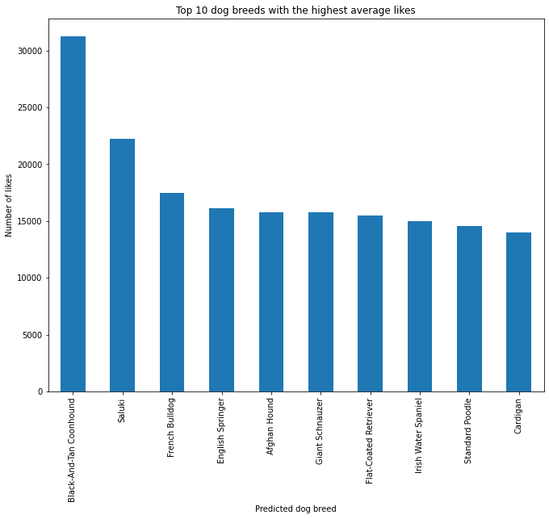

```python
# plotting dog breeds with the highest likes
plt.figure(1, figsize = (11, 8.5))
WRD_clean.groupby('predicted_dog_breed')['favorite_count'].mean().sort_values(ascending=False)[0:10].plot.bar()
plt.xticks(rotation=90);
plt.title('Top 10 dog breeds with the highest average likes')
plt.xlabel('Predicted dog breed')
plt.ylabel('Number of likes');
```

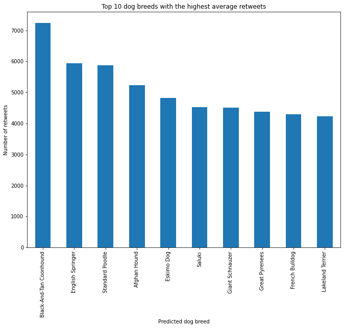

```python
# plotting dog breeds with the highest retweets
plt.figure(1, figsize = (11, 8.5))
WRD_clean.groupby('predicted_dog_breed')['retweet_count'].mean().sort_values(ascending=False)[0:10].plot.bar()
plt.xticks(rotation=90);
plt.title('Top 10 dog breeds with the highest average retweets')
plt.xlabel('Predicted dog breed')
plt.ylabel('Number of retweets');
```

**Observation:** seems like Black-and-Tan Coonhound is the highest liked and retweeted dog breed, let's also check it WRD rating

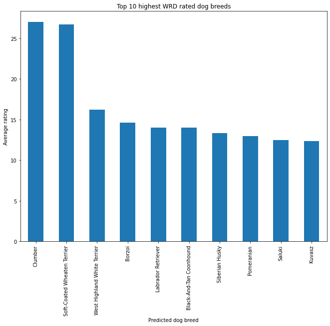

```python
# plotting dog breeds with the highest WRD rating
plt.figure(1, figsize = (11, 8.5))
WRD_clean.groupby('predicted_dog_breed')['rating_numerator'].mean().sort_values(ascending=False)[:10].plot.bar()
plt.title('Top 10 highest WRD rated dog breeds')
plt.xlabel('Predicted dog breed')
plt.ylabel('Average rating');
```

Although not the highest average rating, the black-and-tan coonhound is among the top 10 highest rated breeds as well

**Analysis 2:** Which dogs breeds are most popular amongst dog owners? In this case, we will count "populairty" based on the number of submissions to WRD by dog breed

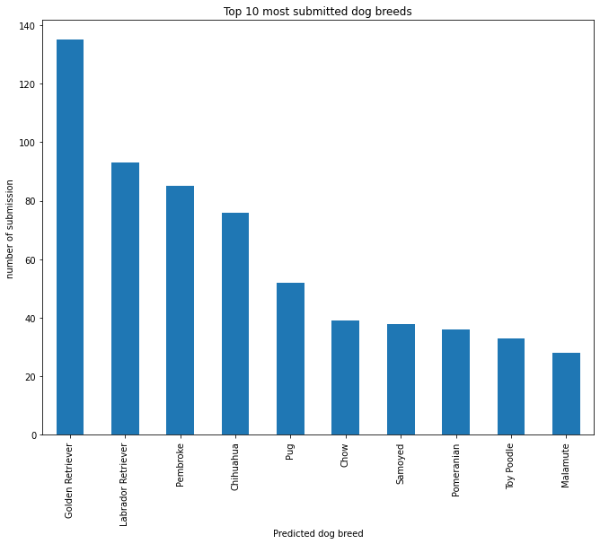

```python
# Most submitted dog breeds
plt.figure(1, figsize = (11, 8.5))
WRD_clean['predicted_dog_breed'].value_counts().sort_values(ascending=False)[0:10].plot.bar();
plt.title('Top 10 most submitted dog breeds')
plt.xlabel('Predicted dog breed')
plt.ylabel('number of submission');
```

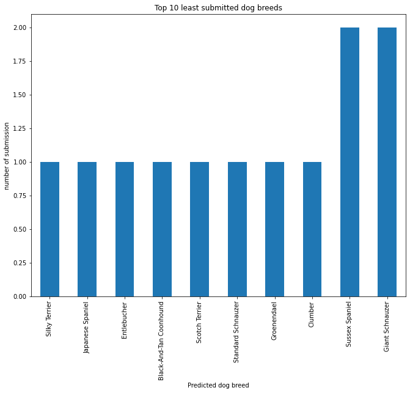

```python
# Least submitted dog breeds
plt.figure(1, figsize = (11, 8.5))
WRD_clean['predicted_dog_breed'].value_counts().sort_values(ascending=True)[0:10].plot.bar();
plt.title('Top 10 least submitted dog breeds')
plt.xlabel('Predicted dog breed')
plt.ylabel('number of submission');
```

**Analysis 3:** relationship between dog breed and prediction confidence. Could the ML algorithm predict certain breeds with higher average confidence than others?

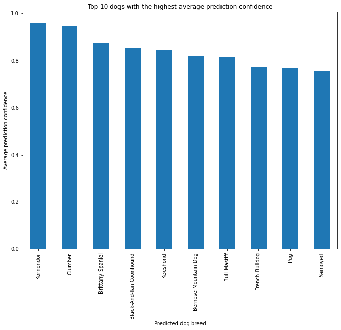

```python
# plotting dog breeds with the most confident predictions
plt.figure(1, figsize = (11, 8.5))
WRD_clean.groupby('predicted_dog_breed')['prediction_confidence'].mean().sort_values(ascending=False)[0:10].plot.bar()
plt.title('Top 10 dogs with the highest average prediction confidence')
plt.xlabel('Predicted dog breed')
plt.ylabel('Average prediction confidence');
```

How about the 10 least confident breeds?

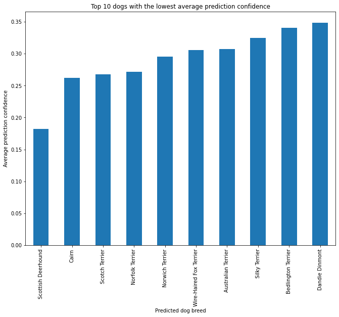

```python
# plotting dog breeds with the least confident predictions
plt.figure(1, figsize = (11, 8.5))
WRD_clean.groupby('predicted_dog_breed')['prediction_confidence'].mean().sort_values(ascending=True)[0:10].plot.bar()
plt.title('Top 10 dogs with the lowest average prediction confidence')
plt.xlabel('Predicted dog breed')
plt.ylabel('Average prediction confidence');
```

**Observations**: The komondor has the highest prediction average(maybe due to it unique look) at ~0.96, while the Scottish Deerhound is the least confident at ~0.19

**Analysis 4:** How does the dog stage (relative age of dogs) affect the prediction confidence of the ML algorithm?

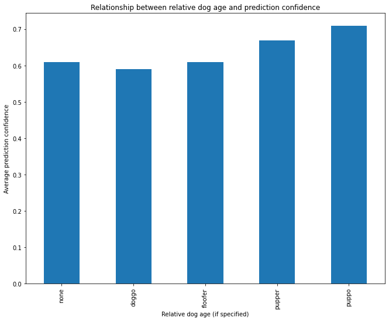

```python
# plotting the relationship between relative dog age and prediction confidence
plt.figure(1, figsize = (11, 8.5))
WRD_clean.groupby('dog_stage')['prediction_confidence'].mean()[['none', 'doggo', 'floofer', 'pupper', 'puppo']].plot.bar();
plt.title('Relationship between relative dog age and prediction confidence')
plt.xlabel('Relative dog age (if specified)')
plt.ylabel('Average prediction confidence');
```

**Analysis 5:** Trend of retweets and likes over time. As the Twitter page grows over time, how does the average number of likes and retweets reflect this growth

```python
#let's first make a new df and sort by the timestamp

page_growth = WRD_clean[['timestamp', 'favorite_count', 'retweet_count']]
page_growth = page_growth.sort_values(by=['timestamp'])

#dropping any rows with missing value

page_growth=page_growth.dropna()
page_growth.retweet_count
```

```
1604     462.0
1600      39.0
1593      53.0
1592     146.0
1591      41.0
         ...
4       1851.0
3       2841.0
2       8489.0
1       3781.0
0       5705.0
Name: retweet_count, Length: 1529, dtype: float64
```

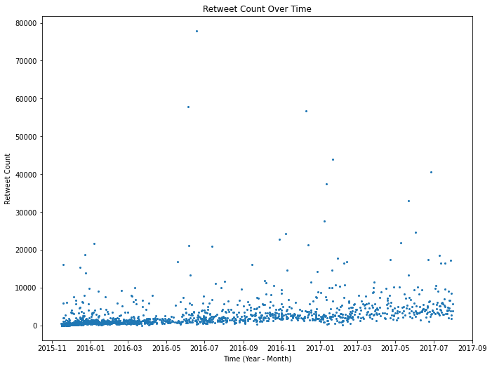

```python
# Plotting number of retweets over time
plt.figure(1, figsize = (11, 8.5))
plt.plot(page_growth.timestamp ,page_growth.retweet_count, marker = 'o', linestyle = '', ms = 2)
plt.title('Retweet Count Over Time')
plt.xlabel('Time (Year - Month)')
plt.ylabel('Retweet Count')
plt.show()
```

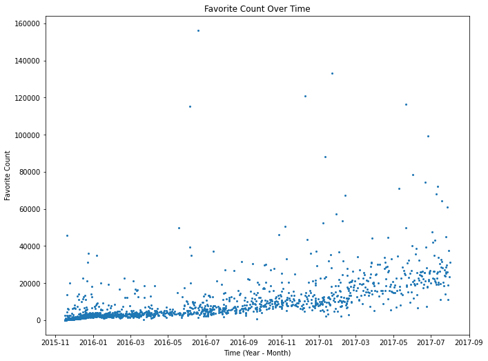

```python
# Plotting number of likes over time
plt.figure(1, figsize = (11, 8.5))
plt.plot(page_growth.timestamp ,page_growth.favorite_count, marker = 'o', linestyle = '', ms = 2)
plt.title('Favorite Count Over Time')
plt.xlabel('Time (Year - Month)')
plt.ylabel('Favorite Count')
plt.show()
```

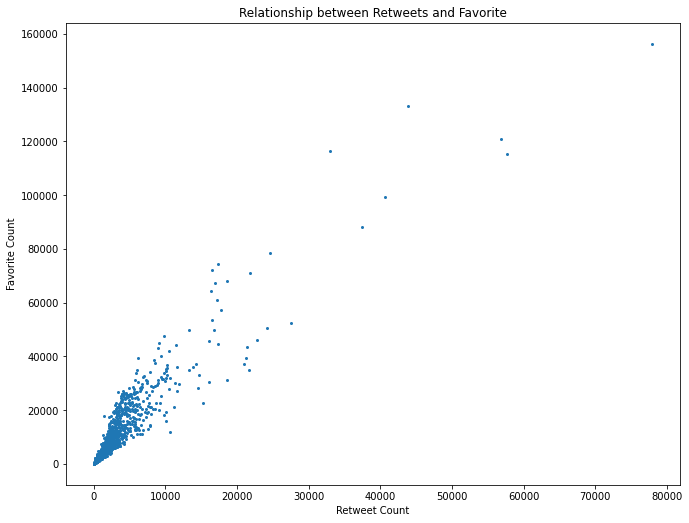

```python
# plotting retweets as a function of likes
plt.figure(1, figsize = (11, 8.5))
plt.plot(page_growth.retweet_count ,page_growth.favorite_count, marker = 'o', linestyle = '', ms = 2)
plt.title('Relationship between Retweets and Favorite')
plt.xlabel('Retweet Count')
plt.ylabel('Favorite Count')
plt.show()
```

**Observation:** Hard to definitively tell the trends, let's convert `favorite_count` and `retweet_count` to logscale

```python
# converting favorite_count and retweet_count to logscale
to_log = ['favorite_count', 'retweet_count']
df_logged = page_growth[to_log].applymap(lambda x: np.log10(x))
```

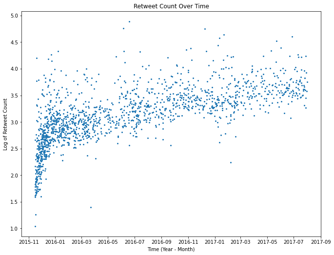

```python
# Plotting log (number of retweets) over time
plt.figure(1, figsize = (11, 8.5))
plt.plot(page_growth.timestamp ,df_logged.retweet_count, marker = 'o', linestyle = '', ms = 2)
plt.title('Retweet Count Over Time')
plt.xlabel('Time (Year - Month)')
plt.ylabel('Log of Retweet Count')
plt.show()
```

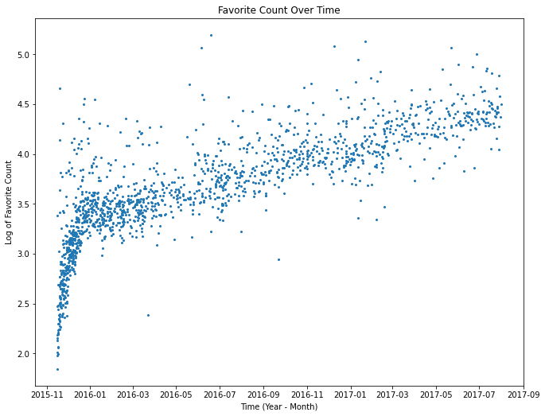

```python
# Plotting log (number of likes) over time
plt.figure(1, figsize = (11, 8.5))
plt.plot(page_growth.timestamp ,df_logged.favorite_count, marker = 'o', linestyle = '', ms = 2)
plt.title('Favorite Count Over Time')
plt.xlabel('Time (Year - Month)')
plt.ylabel('Log of Favorite Count')
plt.show()
```

```python
# Plotting log (number of retweets) as a function of log (number of likess)
over time
plt.figure(1, figsize = (11, 8.5))
plt.plot(df_logged.retweet_count ,df_logged.favorite_count, marker = 'o', linestyle = '', ms = 2)
plt.title('Relationship between Retweets and Favorites')
plt.xlabel('Log of Retweet_count')
plt.ylabel('Log of Favorite Count')
plt.show()
```

[output not shown]

[output not shown]

[output not shown]

**Observation:** Much better, and we can observe the was a period of sharp increase for both retweets and likes between Nov. 2015 and Jan. 2016, before flattening out and growing more steadily. For the relationship between number of retweets and number of likes, the linear relationship indicates that typically higher liked tweets will also receive more retweets and vice versa, this is to be expected.